# A data scraping tool for stock tickers

Using stackoverflow and medium as sources

Faes E., Antwerp Management School

April 13 2021

### Data

Web scraped table

| Company | Ticker |  | Exchange | Sector | Market Cap |
| --- | --- | --- | --- | --- | --- |
| Ackermans & Van Haaren | ACKB | 🇧🇪 | Euronext Brussels | General Industrials | €4.5bn |
| Ageas SA/NV | AGS | 🇧🇪 | Euronext Brussels | Life Insurance | €12.5bn |
| Anheuser-Busch In Bev SA/NV | ABI | 🇧🇪 | Euronext Brussels | Beverages | €87.9bn |
| Bpost S.A. / N.V | BPOST | 🇧🇪 | Euronext Brussels | Support Services | €1.7bn |
| Cofinimmo | COFB | 🇧🇪 | Euronext Brussels | Real Estate Investment & Services | €2.1bn |
| Colruyt | COLR | 🇧🇪 | Euronext Brussels | Food and Drug Retailers | €7.9bn |
| Elia Group | ELI | 🇧🇪 | Euronext Brussels | Electricity | €5.5bn |
| Galapagos NV | GLPG | 🇳🇱 | Euronext Amsterdam | Pharmaceuticals & Biotechnology | €3.0bn |
| Groupe Bruxelles Lambert (New) | GBLB | 🇧🇪 | Euronext Brussels | General Industrials | €14.2bn |
| ING Groep N.V. | INGA | 🇳🇱 | Euronext Amsterdam | Banks | €39.7bn |
| KBC Group SA NV | KBC | 🇧🇪 | Euronext Brussels | Banks | €21.4bn |
| Koninklijke Ahold Delhaize N.V. | AD | 🇳🇱 | Euronext Amsterdam | Food and Drug Retailers | €25.1bn |
| NV Bekaert SA. | BEKB | 🇧🇪 | Euronext Brussels | Industrial Engineering | €2.2bn |
| Ontex Group NV | ONTEX | 🇧🇪 | Euronext Brussels | Personal Goods | €600mn |
| Proximus | PROX | 🇧🇪 | Euronext Brussels | Telecomms | €6.0bn |
| Solvay SA | SOLB | 🇧🇪 | Euronext Brussels | Chemicals | €8.6bn |
| Telenet Group Hldgs NV | TNET | 🇧🇪 | Euronext Brussels | Telecomms | €4.0bn |
| UCB SA | UCB | 🇧🇪 | Euronext Brussels | Pharmaceuticals & Biotechnology | €14.2bn |
| Umicore | UMI | 🇧🇪 | Euronext Brussels | Industrial Metals | €5.2bn |

Note:

This table is retrieved from dividendmax.com

### Getsymbols

However, if you look at column Ticker in the table Belgian stocks are ofcourse somewhat different on Yahoo Finance: we have to add .BR (Brussels Stock Exchange) to each word. Also there are some Dutch stocks in there which we will have to add .AS for. We can easily do this in R with an if statement within a loop.

Used a code from “Using getSymbols to Load Financial Data (R)” by Carrie Lo on medium.com to download all prices from April 2016 (5 years in the past) at once with progress bar in long format.

Yahoo finance API datatable (first 5 rows)

| Date | Symbol | Open | High | Low | Close | Volume | Adjusted |
| --- | --- | --- | --- | --- | --- | --- | --- |
| 2016-04-18 | ACKB.BR | 113.50 | 115.50 | 113.00 | 114.60 | 36957 | 105.536 |
| 2016-04-19 | ACKB.BR | 114.75 | 115.35 | 113.80 | 113.95 | 38001 | 104.938 |
| 2016-04-20 | ACKB.BR | 113.70 | 113.80 | 111.65 | 112.20 | 46726 | 103.326 |
| 2016-04-21 | ACKB.BR | 112.20 | 112.75 | 111.35 | 111.75 | 43270 | 102.912 |
| 2016-04-22 | ACKB.BR | 111.50 | 111.90 | 110.65 | 110.80 | 42083 | 102.037 |

Note:  
This data is directly retrieved from Yahoo Finance

If we want the sector and company later on, we definitely have to merge the yahoo finance table with the scraped table

Merged table (first 5 rows)

| Symbol | Date | Open | High | Low | Close | Volume | Adjusted | Company | Sector |
| --- | --- | --- | --- | --- | --- | --- | --- | --- | --- |
| ABI.BR | 2016-04-18 | 110.6 | 112.85 | 110.55 | 112.45 | 1175066 | 92.754 | Anheuser-Busch In Bev SA/NV | Beverages |
| ABI.BR | 2016-04-19 | 112.8 | 116.80 | 112.65 | 115.45 | 1950443 | 95.228 | Anheuser-Busch In Bev SA/NV | Beverages |
| ABI.BR | 2016-04-20 | 115.1 | 116.20 | 114.35 | 116.10 | 1244869 | 95.765 | Anheuser-Busch In Bev SA/NV | Beverages |
| ABI.BR | 2016-04-21 | 116.1 | 116.35 | 112.55 | 114.50 | 1535007 | 94.445 | Anheuser-Busch In Bev SA/NV | Beverages |
| ABI.BR | 2016-04-22 | 114.7 | 114.80 | 112.95 | 113.35 | 1033538 | 93.496 | Anheuser-Busch In Bev SA/NV | Beverages |

### Log-returns visual

If we want to want to make some nice visualizations like the evolution of the time series (log returns) or Prices.

[interactive chart not shown]

## Some other nice Visualizations

### Prices visual

We of course want to do this on daily/monthly returns, simple returns! not log. Here they are also visualized using Highchart.

[interactive chart not shown]

[output not shown]

### To visualize gross returns:

[interactive chart not shown]

## Portfolio construction

How will we allocate our positions? Let’s first look at Harry M. Markowitz: mean-variance portfolio (least risk), tangency portfolio (max risk-return trade-off) and the efficient frontier. I know it’s a theory that is far from optimal for portfolio construction, but let’s do it anyways

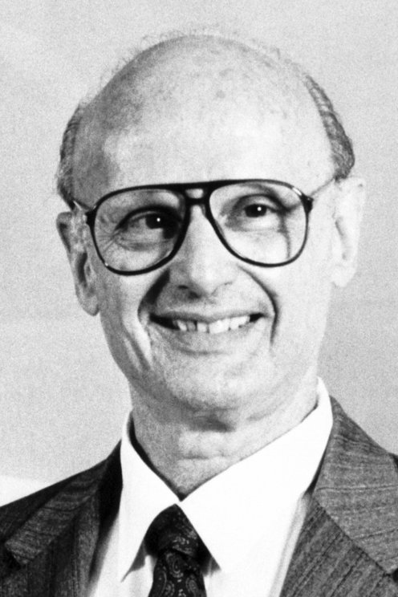

Let’s look at the Mean variance graph by prof. dr. [Annaert](https://www.antwerpmanagementschool.be/nl/faculty/jan-annaert).

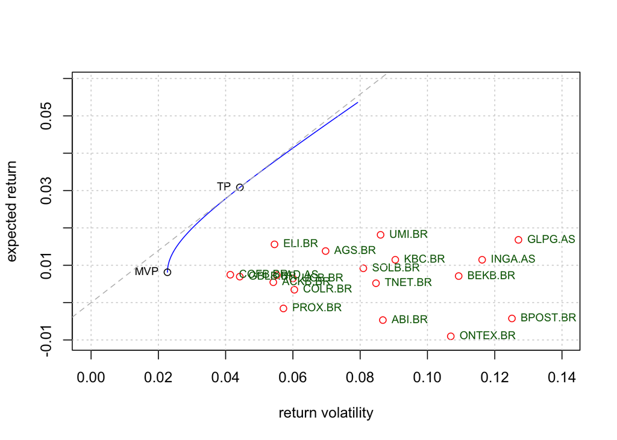

## Data source

BEL 20 Constituents. (2021). Dividendmax.com. https://www.dividendmax.com/market-index-constituents/bel-20 ‌

## Works used

R-bloggers. (2015). R-Bloggers. https://www.r-bloggers.com/author/cory-nissen/ ‌

Using rvest to Scrape an HTML Table | R-bloggers. (2015, January 8). R-Bloggers. https://www.r-bloggers.com/2015/01/using-rvest-to-scrape-an-html-table/ ‌